The first code chunk contains variables that needs to be defined before running the code.

## General Parameters and Statistics

Here is an overview about GPNAE network annotations by each layer:

```r
# no and type of seeds
length(gpnae)
```

```
## [1] 19
```

```r
gpnae
```

```
##  [1] "Cluster_1071" "Cluster_1165" "Cluster_1246" "Cluster_1267" "Cluster_1277"
##  [6] "Cluster_1334" "Cluster_1332" "Cluster_1349" "Cluster_1359" "Cluster_1488"
## [11] "Cluster_1492" "Cluster_1562" "Cluster_1615" "Cluster_1749" "Cluster_1812"
## [16] "Cluster_1813" "Cluster_1834" "Cluster_1856" "Cluster_2113"
```

Next, we get an overview about the number of annotations that have been made with the algorithm.

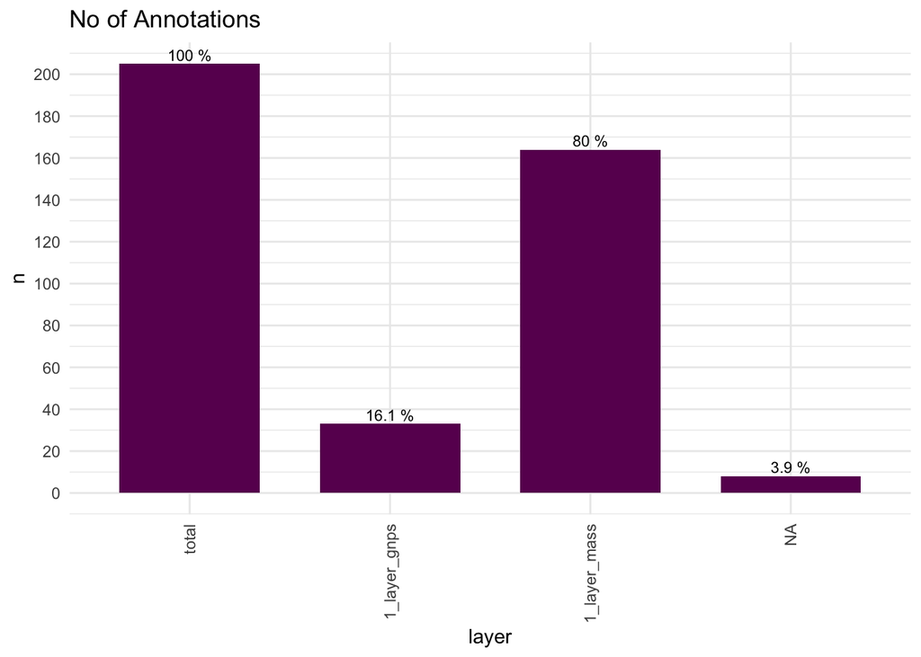

```r
# png(paste0(paste0(seeds_fold, "GPNAE_NoOfAnnotations.png")),
#     width = 800, height = 400, res = 100)

ggplot(data = df_a, aes(x = layer, y = n)) +
  geom_bar(stat = "identity", width = 0.7, fill = "#69005f") +
  geom_text(aes(label = perc), vjust = -0.3, size = 3) +
  labs(title = "No of Annotations") +
  theme_minimal() +
  scale_y_continuous(breaks = pretty_breaks(n = 12)) +
  theme(axis.text.x = element_text(angle = 90, vjust = 0.5, hjust = 1))
```

```r
# dev.off()


# overview of number of network annotations:
table(results_top$network_layer)
```

```
##
##  1_layer_gnps 1_layer_homol  1_layer_mass
##            33             8           164
```

## Validation using SIRIUS

The SIRIUS file is loaded all its molecular formula are used and matched against all molecular formula that have been determined by the network propagation algorithm. If there is any match, the entry will be “yes”, if there is none it will be “no”. If there is no molecular formula available, either in SIRIUS nor in the annotated species, the entry will be “NA”.

The first plot shows all matches including NA’s, whereas the second plot removed the NA’s, in order to better evaluate the matching annotations. The second plot provides the information of the percentage of features that have a matching and a miss-matching molecular formula (number of NA are not considered.)

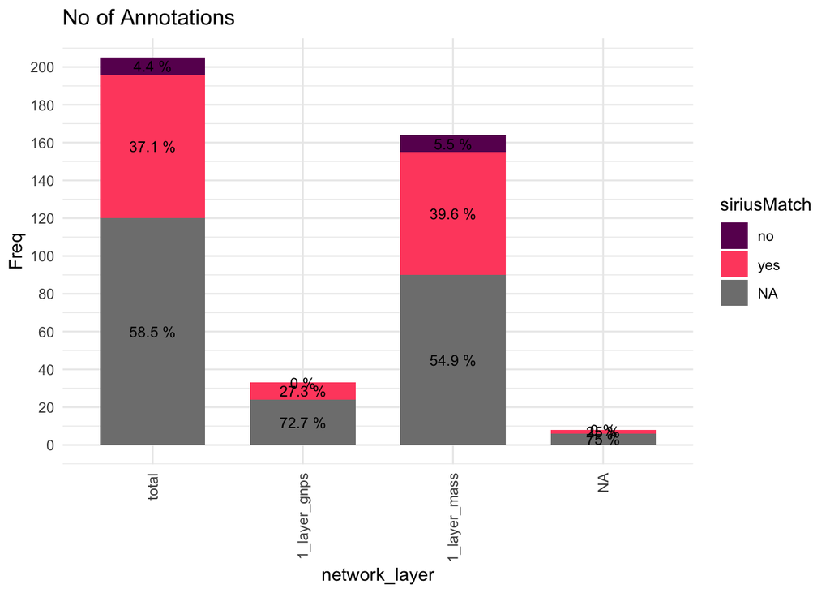

```r
ggplot(data = df_s, aes(x = network_layer, y = Freq, fill = siriusMatch)) +
  geom_bar(stat = "identity", width = 0.7, position = "stack") +
  geom_text(aes(label = perc), position = position_stack(vjust = 0.5), size = 3.2) +
  labs(title = "No of Annotations") +
  theme_minimal() +
  scale_fill_manual(values = c("#69005f", "#ff506e", "black")) +
  scale_y_continuous(breaks = pretty_breaks(n = 12)) +
  theme(axis.text.x = element_text(angle = 90, vjust = 0.5, hjust = 1))
```

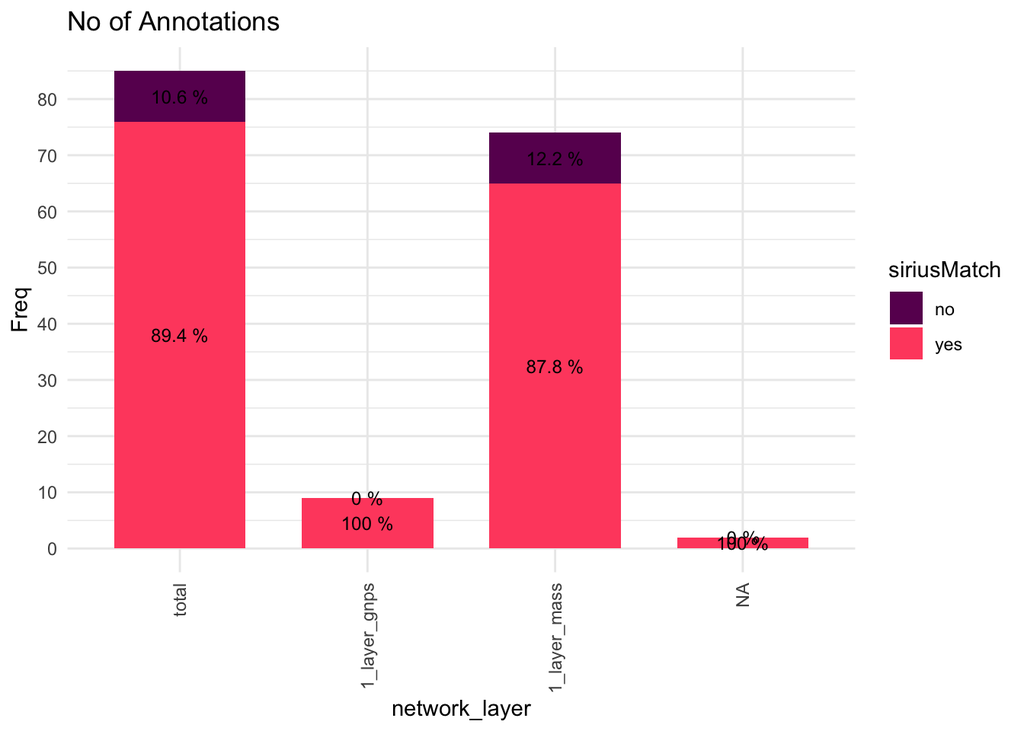

```r
ggplot(data = df_s[!is.na(df_s$siriusMatch), ] %>% group_by(network_layer) %>%
  mutate(perc = paste0((round(Freq / sum(Freq) * 100, 1)), " %")),
  aes(x = network_layer, y = Freq, fill = siriusMatch)) +
  geom_bar(stat = "identity", width = 0.7, position = "stack") +
  geom_text(aes(label = perc), position = position_stack(vjust = 0.5), size = 3.2) +
  labs(title = "No of Annotations") +
  theme_minimal() +
  scale_fill_manual(values = c("#69005f", "#ff506e", "black")) +
  scale_y_continuous(breaks = pretty_breaks(n = 12)) +
  theme(axis.text.x = element_text(angle = 90, vjust = 0.5, hjust = 1))
```

## Mass difference evaluation of annotated features

In this section we compare the observed mass-differences of 1) the first neighbors of the gpnae seed nodes 2) between the seeds and the features that have been annotated 3) between the seeds and the features that not have been annotated 4) between the seeds and the features that have been annotated, but don’t have an spectral similarity edge

In order to get an overview of the appearance of mass-differences that are more frequently used for the annotation of GPNAE’s.

Summary of mass differences of:

```r
# first neighbors of seeds
head(tab_firstNeighbors)
```

```
##                  Var1 Freq
## 1  Ethylation (+C2H4)   68
## 2                C2H2   66
## 3                  C2   56
## 4 Hydrogenation (+H2)   50
## 5  Methylation (+CH2)   43
## 6                C3H6   38
```

```r
# Annotated nodes
head(tab_Annotated)
```

```
##                  Var1 Freq
## 1                C2H2   65
## 2  Ethylation (+C2H4)   65
## 3                  C2   52
## 4 Hydrogenation (+H2)   48
## 5  Methylation (+CH2)   41
## 6    Hexose (C6H10O5)   37
```

```r
# NOT Annotated nodes
if (length(NonAnnotated) != 0) {
head(tab_NonAnnotated)
}
# Annotated nodes but without spectral similarity
head(tab_AnnotatedNoSimil)
```

```
##                  Var1 Freq
## 1  Ethylation (+C2H4)   51
## 2                C2H2   48
## 3                  C2   39
## 4    Hexose (C6H10O5)   37
## 5 Hydrogenation (+H2)   36
## 6  Methylation (+CH2)   33
```

```r
# Annotated nodes that match to SIRIUS molecular formula
head(tab_Annotated_sirY)
```

```
##                  Var1 Freq
## 1  Ethylation (+C2H4)   38
## 2                C2H2   37
## 3  Methylation (+CH2)   29
## 4                  C2   25
## 5 Hydrogenation (+H2)   24
## 6    Hexose (C6H10O5)   20
```

```r
# Annotated nodes that NOT match to SIRIUS  molecular formula
head(tab_Annotated_sirN)
```

```
##                     Var1 Freq
## 1 Isoprenylation (+C5H8)    5
## 2     Methylation (+CH2)    4
## 3       Amination (+NH3)    2
## 4                     C2    2
## 5                    CH4    2
## 6       Amination (+NH2)    1
```

## Glucose annotations

The annotation of Glucose variants of GPNAEs is mainly accomplished by propagation in die mass-difference layer because the MS2 spectra are too different. Therefore, this section evaluates the properties of the Glucose annotations of this dataset. First, we want to create a sub-network and keep glucose annotations only.

```r
annoGluc <- results_top[results_top$network_annotation %like% "C6H10O5", ]

#Number of Glucose annotations
nrow(annoGluc)
```

```
## [1] 33
```

```r
#Number of ms2 available at Glucose annotations
table(annoGluc$ms2_available)
```

```
##
##  No Yes
##  15  18
```

```r
#Layer that have been used for Glucose annotation
table(annoGluc$network_layer)
```

```
##
## 1_layer_mass
##           33
```

```r
## how many with sirius correct
table(annoGluc$siriusMatch)
```

```
##
## yes
##  18
```

how many spec edges within glucose sub network and their mean spectral similarity

```r
# number of glucose annotations that have spectral similarity within each other
length(inner_glu[!is.na(inner_glu$gnps_cosine), ]$gnps_cosine)
```

```
## [1] 20
```

```r
# mean spectral similarity
mean(inner_glu[!is.na(inner_glu$gnps_cosine), ]$gnps_cosine)
```

```
## [1] 0.92124
```

### Evaluation of benefits of Homol Series

We test if we see any benefits/ better annotation by features that are somehow connected in the homologous series network, because they are more likely to be real biological features because of the RT trends. Therefore we create a sub network, where we remove all features that show no connection in the homologous series layer.

```r
# remove nodes that have no homol series (from original file)
homol_net <- net_df[!is.na(net_df$HSIDs), ]

#get cluster_ID of the nodes that appear on homol series layer
homols <- unique(c(homol_net$from, homol_net$to))

# filter results file by those features appearing in homol series
results_homol <- results_top[results_top$Row %in% homols, ]


## how many left
nrow(results_homol)
```

```
## [1] 164
```

```r
nrow(results_top)
```

```
## [1] 205
```

```r
#Layer that have been used for annotation
table(results_homol$network_layer)
```

```
##
##  1_layer_gnps 1_layer_homol  1_layer_mass
##            28             8           128
```

```r
table(results_top$network_layer)
```

```
##
##  1_layer_gnps 1_layer_homol  1_layer_mass
##            33             8           164
```

```r
## how many with MS2
table(results_homol$ms2_available)
```

```
##
##  No Yes
##  73  91
```

```r
table(results_top$ms2_available)
```

```
##
##  No Yes
##  93 112
```

```r
## how many with sirius correct compared to all nodes
table(results_homol$siriusMatch)
```

```
##
##  no yes
##   7  62
```

```r
table(results_top$siriusMatch)
```

```
##
##  no yes
##   9  76
```

#### Evaluation using Glucose Annotations

```r
## create subnetwork with Glucose nodes and nodes that appeat in homol series
annoGluc_homol <- results_homol[results_homol$network_annotation %like% "C6H10O5", ]

## how many left
nrow(annoGluc_homol)
```

```
## [1] 28
```

```r
#Layer that have been used for Glucose annotation
table(annoGluc_homol$network_layer)
```

```
##
## 1_layer_mass
##           28
```

```r
## how many with MS2
table(annoGluc_homol$ms2_available)
```

```
##
##  No Yes
##  13  15
```

```r
## how many with sirius correct
table(annoGluc_homol$siriusMatch)
```

```
##
## yes
##  15
```

## Validation using manually Annotated nodes

In order to verify how good annotations are with the network propagation algorithm, we next create a sub network were we only keep nodes where we have an manual annotation (i.e. a molecular formula for matching). With that we can first validate how good our annotations are and secondly, validate if filtering nodes for the homologous series increases our annotation success or if we just lose important annotations.

```r
#how many does match
nrow(Match)
```

```
## [1] 40
```

```r
#how many does NOT match
nrow(noMatch)
```

```
## [1] 1
```

```r
#comment on network to see what e.g. mass differences can be excluded
noMatch$network_comment
```

```
## [1] "simil:NA; mzdiff:Hexose (C6H10O5); homol HSID:NA; homol RT:NA"
```

### Test if homol series increase the success

```r
## test how many homols have key fragments
table(select(results_top, homol, key_fragments))
```

```
## < table of extent 2 x 0 >
```

```r
## test how many homols in 2_layer annotation gnps+mass
table(results_top[results_top$network_layer == "2_layers_gnps_mass", ]$homol)
```

```
## < table of extent 0 >
```

```r
## test how many homols in 1_layer annotation gnps
table(results_top[results_top$network_layer == "1_layer_gnps", ]$homol)
```

```
##
##  no yes
##   5  28
```

```r
homol_valid <- merge(results_homol, validMol, by = "Row", all.x = TRUE)

homol_valid <- homol_valid %>%
  select(Row, `m.z`, RT, "Annotation.ID.x", "formula",
         "ms2_available", "network_annotation", "network_formula",
         "Annotation.ID.y","molFormula",
         "network_inputNode", "network_layer",
         "network_comment", "key_fragments"
         )


homol_valid$validMolMatch <- ifelse(sapply(
  lapply(homol_valid$network_formula, grepl,
    x = homol_valid$molFormula
  ),
  any
), "yes", "no")

homol_valid$validMolMatch <- ifelse(is.na(homol_valid$molFormula),
                                  NA,homol_valid$validMolMatch)


noMatchHomol <- homol_valid[homol_valid$validMolMatch == "no" &
                           !is.na(homol_valid$validMolMatch), ]

MatchHomol <- homol_valid[homol_valid$validMolMatch == "yes" &
                           !is.na(homol_valid$validMolMatch), ]


#how many does match
nrow(MatchHomol)
```

```
## [1] 37
```

```r
#how many does NOT match
nrow(noMatchHomol)
```

```
## [1] 1
```

```r
#comment on network to see what e.g. mass differences can be excluded
noMatchHomol$network_comment
```

```
## [1] "simil:NA; mzdiff:Hexose (C6H10O5); homol HSID:NA; homol RT:NA"
```

```r
## get differences between matches of homol series
## filtered results file and normal file


diff <- anti_join( Match, MatchHomol)
```

[output not shown]

```r
# All those annotations are missed when using homol series to filter all nodes:
diff$Annotation.ID.y
```

```
## [1] "LPE(18:3)" NA          NA
```

```r
# check which layers are affected

diff$network_layer
```

```
## [1] "1_layer_mass" "1_layer_mass" "1_layer_mass"
```

#### plot homols

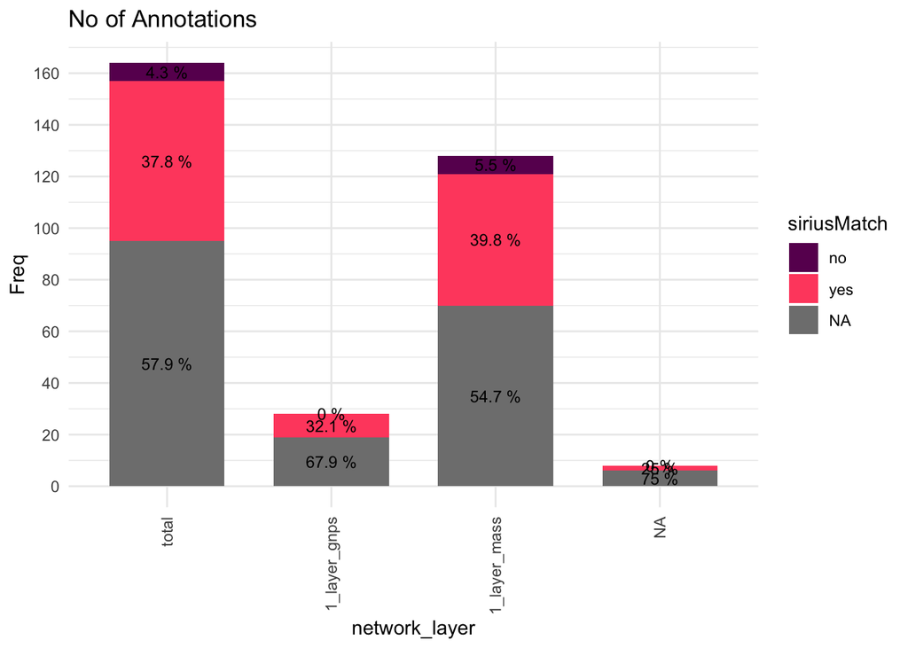

```r
## SIRIUS matches when molecules are part of homol series

ggplot(data = df_s, aes(x = network_layer, y = Freq, fill = siriusMatch)) +
  geom_bar(stat = "identity", width = 0.7, position = "stack") +
  geom_text(aes(label = perc), position = position_stack(vjust = 0.5), size = 3.2) +
  labs(title = "No of Annotations") +
  theme_minimal() +
  scale_fill_manual(values = c("#69005f", "#ff506e", "black")) +
  scale_y_continuous(breaks = pretty_breaks(n = 12)) +
  theme(axis.text.x = element_text(angle = 90, vjust = 0.5, hjust = 1))
```

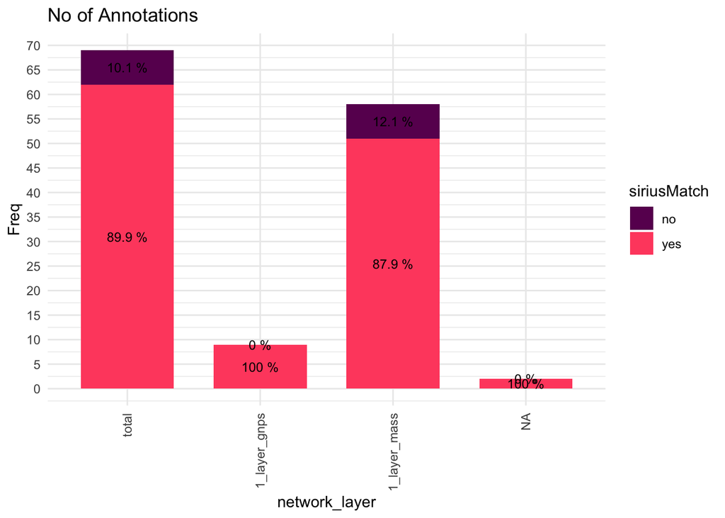

```r
ggplot(data = df_s[!is.na(df_s$siriusMatch), ] %>% group_by(network_layer) %>%
  mutate(perc = paste0((round(Freq / sum(Freq) * 100, 1)), " %")),
  aes(x = network_layer, y = Freq, fill = siriusMatch)) +
  geom_bar(stat = "identity", width = 0.7, position = "stack") +
  geom_text(aes(label = perc), position = position_stack(vjust = 0.5), size = 3.2) +
  labs(title = "No of Annotations") +
  theme_minimal() +
  scale_fill_manual(values = c("#69005f", "#ff506e", "black")) +
  scale_y_continuous(breaks = pretty_breaks(n = 12)) +
  theme(axis.text.x = element_text(angle = 90, vjust = 0.5, hjust = 1))
```

#### plot results_top

1_layer_mass is now filtered: Only those nodes are kept that show any homol series

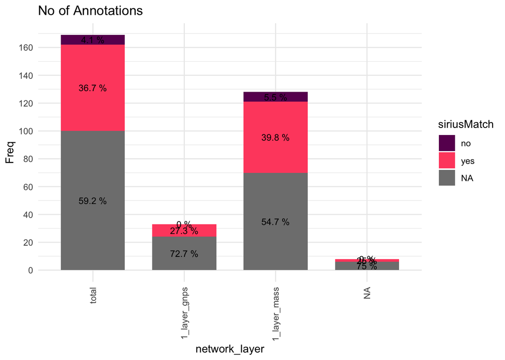

```r
## SIRIUS matches when molecules are part of homol series

ggplot(data = df_s, aes(x = network_layer, y = Freq, fill = siriusMatch)) +
  geom_bar(stat = "identity", width = 0.7, position = "stack") +
  geom_text(aes(label = perc), position = position_stack(vjust = 0.5), size = 3.2) +
  labs(title = "No of Annotations") +
  theme_minimal() +
  scale_fill_manual(values = c("#69005f", "#ff506e", "black")) +
  scale_y_continuous(breaks = pretty_breaks(n = 12)) +
  theme(axis.text.x = element_text(angle = 90, vjust = 0.5, hjust = 1))
```

```r
table(results_top[!(results_top$homol == "no" &
              results_top$network_layer == "1_layer_mass"),
              "network_layer"]
)
```

```
##
##  1_layer_gnps 1_layer_homol  1_layer_mass
##            33             8           128
```

```r
table(results_top[,
              "network_layer"]
)
```

```
##
##  1_layer_gnps 1_layer_homol  1_layer_mass
##            33             8           164
```

## Annotated as LPEs

```r
## SIRIUS matches when molecules are part of homol series

LPEs <- results_top[grepl("LPE", results_top$Annotation.ID),]

# no of LPEs that were annotates as GPNAEs in the APEX
nrow(LPEs)
```

```
## [1] 23
```

```r
# layers that have been used
table(LPEs$network_layer
)
```

```
##
## 1_layer_homol  1_layer_mass
##             2            21
```

```r
# how many part of homol series
table(LPEs$homol)
```

```
##
##  no yes
##   1  22
```